# Flood data Data

```r
library(tidyverse)
library(janitor)
library(geoarrow)
library(arrow)
library(sf)
library(units)
library(tmap)
```

First, let’s load the ITBI data, the census tracts data, and the flood events data that we have previously collected.

```r
itbi_data <- sfarrow::st_read_parquet("data/itbi/itbi_geocoded.parquet")
# itbi_data$geometry <- st_as_sfc(itbi_data$geometry)
# st_geometry(itbi_data) <- "geometry"
census_tracts <- sfarrow::st_read_parquet("data/census/census_tracts.parquet")
# census_tracts$geometry <- st_as_sfc(census_tracts$geom)
# st_geometry(census_tracts) <- "geometry"
flood_events <- st_read("data/occurrence/flood_events.gpkg")
```

Let’s confirm that all datasets are using the same coordinate reference system (CRS). If they are not, we will need to transform one of them to match the others.

```r
st_crs(itbi_data)
```

```
Coordinate Reference System:
  User input: WGS 84 (CRS84)
  wkt:
GEOGCRS["WGS 84 (CRS84)",
    DATUM["World Geodetic System 1984",
        ELLIPSOID["WGS 84",6378137,298.257223563,
            LENGTHUNIT["metre",1]]],
    PRIMEM["Greenwich",0,
        ANGLEUNIT["degree",0.0174532925199433]],
    CS[ellipsoidal,2],
        AXIS["geodetic longitude (Lon)",east,
            ORDER[1],
            ANGLEUNIT["degree",0.0174532925199433]],
        AXIS["geodetic latitude (Lat)",north,
            ORDER[2],
            ANGLEUNIT["degree",0.0174532925199433]],
    USAGE[
        SCOPE["unknown"],
        AREA["World"],
        BBOX[-90,-180,90,180]],
    ID["OGC","CRS84"]]
```

```r
st_crs(census_tracts)
```

```
Coordinate Reference System:
  User input: SIRGAS 2000
  wkt:
GEOGCRS["SIRGAS 2000",
    DATUM["Sistema de Referencia Geocentrico para las AmericaS 2000",
        ELLIPSOID["GRS 1980",6378137,298.257222101,
            LENGTHUNIT["metre",1]]],
    PRIMEM["Greenwich",0,
        ANGLEUNIT["degree",0.0174532925199433]],
    CS[ellipsoidal,2],
        AXIS["geodetic latitude (Lat)",north,
            ORDER[1],
            ANGLEUNIT["degree",0.0174532925199433]],
        AXIS["geodetic longitude (Lon)",east,
            ORDER[2],
            ANGLEUNIT["degree",0.0174532925199433]],
    USAGE[
        SCOPE["Horizontal component of 3D system."],
        AREA["Latin America - Central America and South America - onshore and offshore. Brazil - onshore and offshore."],
        BBOX[-59.87,-122.19,32.72,-25.28]],
    ID["EPSG",4674]]
```

```r
st_crs(flood_events)
```

```
Coordinate Reference System:
  User input: SIRGAS 2000 / UTM zone 23S
  wkt:
PROJCRS["SIRGAS 2000 / UTM zone 23S",
    BASEGEOGCRS["SIRGAS 2000",
        DATUM["Sistema de Referencia Geocentrico para las AmericaS 2000",
            ELLIPSOID["GRS 1980",6378137,298.257222101,
                LENGTHUNIT["metre",1]]],
        PRIMEM["Greenwich",0,
            ANGLEUNIT["degree",0.0174532925199433]],
        ID["EPSG",4674]],
    CONVERSION["UTM zone 23S",
        METHOD["Transverse Mercator",
            ID["EPSG",9807]],
        PARAMETER["Latitude of natural origin",0,
            ANGLEUNIT["degree",0.0174532925199433],
            ID["EPSG",8801]],
        PARAMETER["Longitude of natural origin",-45,
            ANGLEUNIT["degree",0.0174532925199433],
            ID["EPSG",8802]],
        PARAMETER["Scale factor at natural origin",0.9996,
            SCALEUNIT["unity",1],
            ID["EPSG",8805]],
        PARAMETER["False easting",500000,
            LENGTHUNIT["metre",1],
            ID["EPSG",8806]],
        PARAMETER["False northing",10000000,
            LENGTHUNIT["metre",1],
            ID["EPSG",8807]]],
    CS[Cartesian,2],
        AXIS["(E)",east,
            ORDER[1],
            LENGTHUNIT["metre",1]],
        AXIS["(N)",north,
            ORDER[2],
            LENGTHUNIT["metre",1]],
    USAGE[
        SCOPE["Engineering survey, topographic mapping."],
        AREA["Brazil - between 48°W and 42°W, northern and southern hemispheres, onshore and offshore."],
        BBOX[-33.5,-48,5.13,-42]],
    ID["EPSG",31983]]
```

```r
itbi_data <- st_transform(itbi_data, crs = st_crs(flood_events))
census_tracts <- st_transform(census_tracts, crs = st_crs(flood_events))
```

# Specifying the characteristics of the houses on the observations

## Keeping residential houses only

The first step in preparing the data for the regression model is to filter the itbi_data to keep only the residential houses. We will use the `descricao_do_padrao_iptu` column to filter the data.

```r
itbi_data |>
    st_drop_geometry() |>
    select(descricao_do_padrao_iptu) |>
    distinct() |>
    arrange(descricao_do_padrao_iptu) |>
    DT::datatable()
```

|  | descricao_do_padrao_iptu |
| --- | --- |
| 1 | BARRACÃO/TELHEIRO |
| 2 | BARRACÃO/TELHEIRO, OFICINA, POSTO DE SERVIÇO, ARMAZÉM/DEPÓSITO, INDÚSTRIA |
| 3 | COMERCIAL HORIZONTAL |
| 4 | COMERCIAL VERTICAL |
| 5 | EDIFÍCIO DE GARAGENS |
| 6 | INDÚSTRIA |
| 7 | OFICINA, POSTO DE SERVIÇO, ARMAZÉM/DEPÓSITO, INDÚSTRIA |
| 8 | RESIDENCIAL HORIZONTAL |
| 9 | RESIDENCIAL VERTICAL |
| 10 | TEMPLO, CLUBE, GINÁSIO OU ESTÁDIOESPORTIVO, MUSEU, HIPÓDROMO, CINEMA,TEATRO, AEROPORTO, ESTAÇÕES, ETC. |

[output cut: 2 more lines]

```r
residential_houses <- itbi_data |>
    mutate(year = as.integer(data_year)) |>
    filter(grepl("RESIDENCIAL", descricao_do_padrao_iptu, ignore.case = TRUE) | grepl("RESIDENCIAL", acc_iptu_27, ignore.case = TRUE))

residential_houses |> glimpse()
```

```
Rows: 295,190
Columns: 39
$ n_do_cadastro_sql                              <chr> "6726500084", "37036038…
$ nome_do_logradouro                             <chr> "R JURIPIRANGA", "R DOM…
$ numero                                         <chr> "70", "770", "51", "668…
$ complemento                                    <chr> "ANT 16", "APTO 15", NA…
$ bairro                                         <chr> "PARQUE VITORIA", NA, "…
$ referencia                                     <chr> NA, "ED RESENDE", NA, "…
$ cep                                            <chr> "02269090", "04010903",…
$ natureza_de_transacao                          <chr> "1.Compra e venda", "4.…
$ valor_de_transacao_declarado_pelo_contribuinte <chr> "800000", "359316.34", …
$ data_de_transacao                              <chr> "44918", "44916", "4491…
$ valor_venal_de_referencia                      <chr> "846885", "0", "534585"…
$ proporcao_transmitida_percent                  <chr> "100", "100", "100", "1…
$ valor_venal_de_referencia_proporcional         <chr> "846885", "0", "534585"…
```

[output cut: 26 more lines]

## Selecting the geocoding precision

The next step is to filter the itbi_data to keep only the houses that have been geocoded with a high precision. We will use the `precisao` and `desvio_metros` columns to filter the data. First, let’s check the frequency of the different values in the `precisao` column.

```r
residential_houses |>
    st_drop_geometry() |>
    select(precisao) |>
    group_by(precisao) |>
    summarise(count = n()) |>
    mutate(percentage = count / sum(count) * 100, percentage = round(percentage, 2)) |>
    arrange(desc(count)) |>
    DT::datatable()
```

|  | precisao | count | percentage |
| --- | --- | --- | --- |
| 1 | numero | 216241 | 73.25 |
| 2 | numero_aproximado | 55867 | 18.93 |
| 3 | cep | 11303 | 3.83 |
| 4 | municipio | 8617 | 2.92 |
| 5 | localidade | 3103 | 1.05 |
| 6 | logradouro | 59 | 0.02 |

Most of the houses have been geocoded with a high precision, so let’s drop the houses that have been geocoded by any level above of “numero_aproximado”.

```r
residential_houses <- residential_houses |>
    filter(precisao %in% c("numero", "numero_aproximado"))
residential_houses |> glimpse()
```

```
Rows: 272,108
Columns: 39
$ n_do_cadastro_sql                              <chr> "6726500084", "37036038…
$ nome_do_logradouro                             <chr> "R JURIPIRANGA", "R DOM…
$ numero                                         <chr> "70", "770", "51", "668…
$ complemento                                    <chr> "ANT 16", "APTO 15", NA…
$ bairro                                         <chr> "PARQUE VITORIA", NA, "…
$ referencia                                     <chr> NA, "ED RESENDE", NA, "…
$ cep                                            <chr> "02269090", "04010903",…
$ natureza_de_transacao                          <chr> "1.Compra e venda", "4.…
$ valor_de_transacao_declarado_pelo_contribuinte <chr> "800000", "359316.34", …
$ data_de_transacao                              <chr> "44918", "44916", "4491…
$ valor_venal_de_referencia                      <chr> "846885", "0", "534585"…
$ proporcao_transmitida_percent                  <chr> "100", "100", "100", "1…
$ valor_venal_de_referencia_proporcional         <chr> "846885", "0", "534585"…
```

[output cut: 26 more lines]

Now, let’s check the distribution of the `desvio_metros` column to see if we can filter the data further.

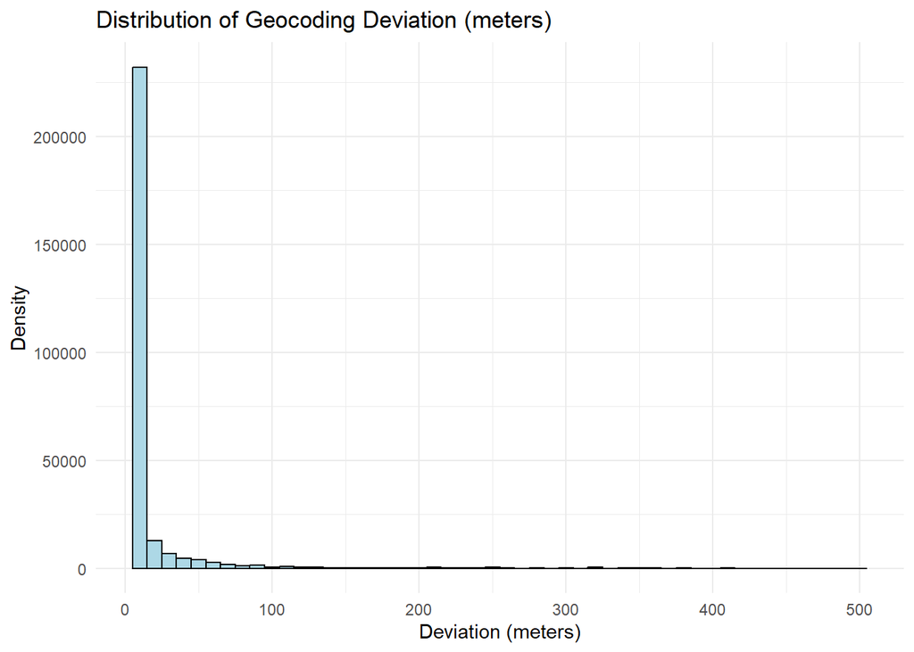

```r
residential_houses |>
    st_drop_geometry() |>
    select(desvio_metros) |>
    filter(!is.na(desvio_metros)) |>
    ggplot(aes(x = desvio_metros)) +
    geom_histogram(binwidth = 10, fill = "lightblue", color = "black") +
    labs(title = "Distribution of Geocoding Deviation (meters)", x = "Deviation (meters)", y = "Density") +
    theme_minimal()
```

Again, most of the houses have a low deviation, so let’s drop the houses that have a deviation above 50 meters.

```r
residential_houses <- residential_houses |>
    filter(desvio_metros <= 50)

residential_houses |> glimpse()
```

```
Rows: 258,640
Columns: 39
$ n_do_cadastro_sql                              <chr> "6726500084", "37036038…
$ nome_do_logradouro                             <chr> "R JURIPIRANGA", "R DOM…
$ numero                                         <chr> "70", "770", "51", "311…
$ complemento                                    <chr> "ANT 16", "APTO 15", NA…
$ bairro                                         <chr> "PARQUE VITORIA", NA, "…
$ referencia                                     <chr> NA, "ED RESENDE", NA, "…
$ cep                                            <chr> "02269090", "04010903",…
$ natureza_de_transacao                          <chr> "1.Compra e venda", "4.…
$ valor_de_transacao_declarado_pelo_contribuinte <chr> "800000", "359316.34", …
$ data_de_transacao                              <chr> "44918", "44916", "4491…
$ valor_venal_de_referencia                      <chr> "846885", "0", "534585"…
$ proporcao_transmitida_percent                  <chr> "100", "100", "100", "1…
$ valor_venal_de_referencia_proporcional         <chr> "846885", "0", "534585"…
```

[output cut: 26 more lines]

## Calculating the distance to the nearest flood event

Now, we will calculate the distance from each census tract to the nearest flood event. We will use the `st_distance` function from the `sf` package to calculate the distance between the census tracts and the flood events.

```r
census_tracts <- census_tracts |>
    # First, enconter the nearest flood event for each house
    mutate(nearest_flood_event_index = st_nearest_feature(geom, flood_events)) |>
    # Then, calculate the distance to the nearest flood event
    mutate(distance_to_nearest_flood_event = st_distance(geom, flood_events[nearest_flood_event_index, ], by_element = TRUE))
    # Lastly, delete the nearest_flood_event column, as we don't need it anymore
    # select(-nearest_flood_event_index)
```

# Creating a panel database of census tracts with the number of transactions and the exposure to flood events

## Creating a base database with the census tracts, years, and months

```r
panel_years <- residential_houses |>
    st_drop_geometry() |>
    distinct(year)

final_database <- expand_grid(
    census_tract = census_tracts$code_tract,
    year = panel_years$year,
    month = seq(1, 12)
) |>
    left_join(census_tracts, by = c("census_tract" = "code_tract")) |>
    st_as_sf()
```

## Calculating the number of transactions per census tract per month

```r
transactions <- st_join(residential_houses, census_tracts |> select(code_tract), join = st_within) |>
    mutate(data_de_transacao = janitor::excel_numeric_to_date(as.numeric(data_de_transacao)),
           month_of_transaction = lubridate::month(data_de_transacao)) |>
    mutate(census_tract = code_tract) |>
    st_drop_geometry() |>
    filter(!is.na(year), !is.na(month_of_transaction)) |>
    mutate(transacted = 1L)
```

```r
final_database <- final_database |>
    left_join(
        transactions |>
            select(census_tract, year, month_of_transaction, transacted) |>
            group_by(census_tract, year, month_of_transaction) |>
            summarise(transactions = sum(transacted), .groups = "drop"),
        by = c("census_tract", "year", "month" = "month_of_transaction"))
```

# Adding flood events to the database

## Adding month and year columns to the flood events data

```r
flood_events <- flood_events |>
    mutate(month = lubridate::month(data),
           year = lubridate::year(data))
```

## Adding census tract information to the flood events data

```r
flood_events <- st_join(flood_events, census_tracts |> select(code_tract), join = st_within) |>
    mutate(census_tract = code_tract) |>
    select(-code_tract)
```

## Adding the number of flood events per census tract per month to the final database

```r
final_database <- final_database |>
    left_join(
        flood_events |>
            st_drop_geometry() |>
            group_by(census_tract, year, month) |>
            summarise(flood_events = n(), .groups = "drop"),
        by = c("census_tract", "year", "month"))
```

# Filtering the final database based on exposure to flood events

```r
final_database_filtered <- final_database |>
    filter(distance_to_nearest_flood_event <= units::set_units(400, "m")) |>
    mutate(flood_events = replace_na(flood_events, 0),
           transactions = replace_na(transactions, 0),
           has_flood_event = if_else(flood_events > 0, 1L, 0L))
```

# Visualizing the database

First, let’s visualize the census tracts categorized by the inclusion criteria of the final database. We will use the `tmap` package to create a map of the census tracts, with the color of the census tracts indicating whether they are included in the final database or not.

```r
library(tmap)

included_tracts <- final_database_filtered |> pull(census_tract) |> unique()
treated_tracts <- final_database_filtered |> filter(has_flood_event == 1) |> pull(census_tract) |> unique()

map_tracts <- census_tracts |>
    mutate(
        included = code_tract %in% included_tracts,
        treated = code_tract %in% treated_tracts,
        category = case_when(
            included & treated ~ "Treated",
            included & !treated ~ "Control",
            !included ~ "Not Included"
        )
    ) |>
    select(-included, -treated)
```

[output not shown]

[output not shown]

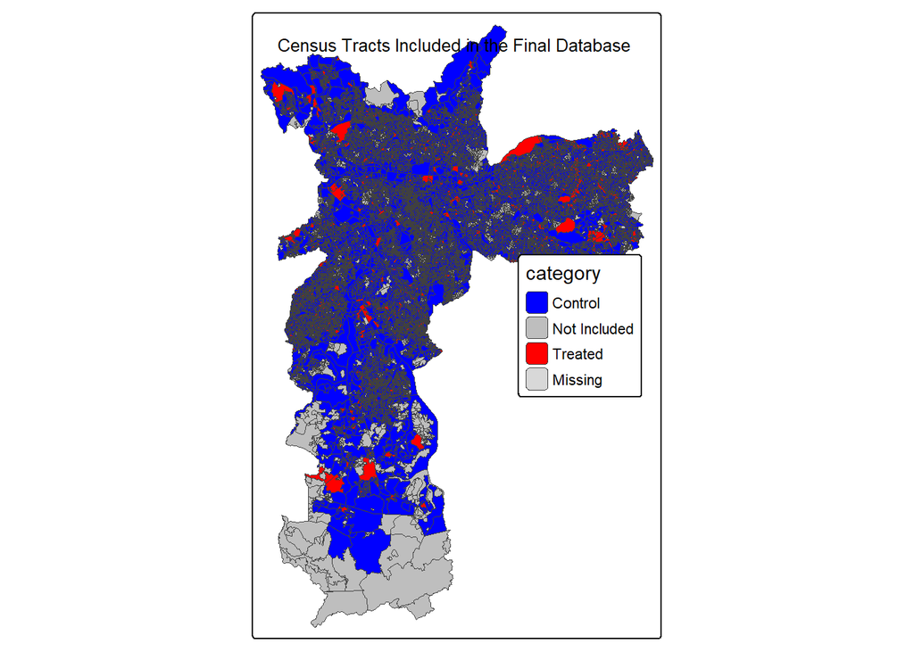

```r
# Plot all the census tracts with grey color
tmap::tm_shape(map_tracts) +
    # Set color based on category, with a color palette of your choice
    tm_polygons(
        col = "category",
        palette = c("Treated" = "red", "Control" = "blue", "Not Included" = "grey"),
        lwd = 0
    ) +
    tm_legend(title = "Census Tract Category", position = c("right", "center")) +
    tm_title("Census Tracts Included in the Final Database", position = c("center", "top"))
```

# Checking the transaction support through the tracts and periods

```r
final_database_filtered |>
    st_drop_geometry() |>
    group_by(year, month) |>
    summarise(transactions = sum(transactions)) |>
    arrange(year, month) |>
    DT::datatable()
```

```
`summarise()` has regrouped the output.
ℹ Summaries were computed grouped by year and month.
ℹ Output is grouped by year.
ℹ Use `summarise(.groups = "drop_last")` to silence this message.
ℹ Use `summarise(.by = c(year, month))` for per-operation grouping
  (`?dplyr::dplyr_by`) instead.
```

|  | year | month | transactions |
| --- | --- | --- | --- |
| 1 | 2023 | 1 | 4092 |
| 2 | 2023 | 2 | 4501 |
| 3 | 2023 | 3 | 6600 |
| 4 | 2023 | 4 | 4826 |
| 5 | 2023 | 5 | 5989 |
| 6 | 2023 | 6 | 6031 |
| 7 | 2023 | 7 | 5413 |
| 8 | 2023 | 8 | 6234 |
| 9 | 2023 | 9 | 5851 |
| 10 | 2023 | 10 | 6220 |

[output cut: 26 more lines]

```r
final_database_filtered |>
    st_drop_geometry() |>
    group_by(census_tract) |>
    summarise(transactions = sum(transactions)) |>
    arrange(transactions) |>
    DT::datatable()
```

|  | census_tract | transactions |
| --- | --- | --- |
| 1 | 355030801000077 | 0 |
| 2 | 355030801000151 | 0 |
| 3 | 355030801000175 | 0 |
| 4 | 355030801000178 | 0 |
| 5 | 355030801000180 | 0 |
| 6 | 355030802000077 | 0 |
| 7 | 355030802000117 | 0 |
| 8 | 355030802000119 | 0 |
| 9 | 355030802000120 | 0 |
| 10 | 355030802000121 | 0 |

[output cut: 24309 more lines]

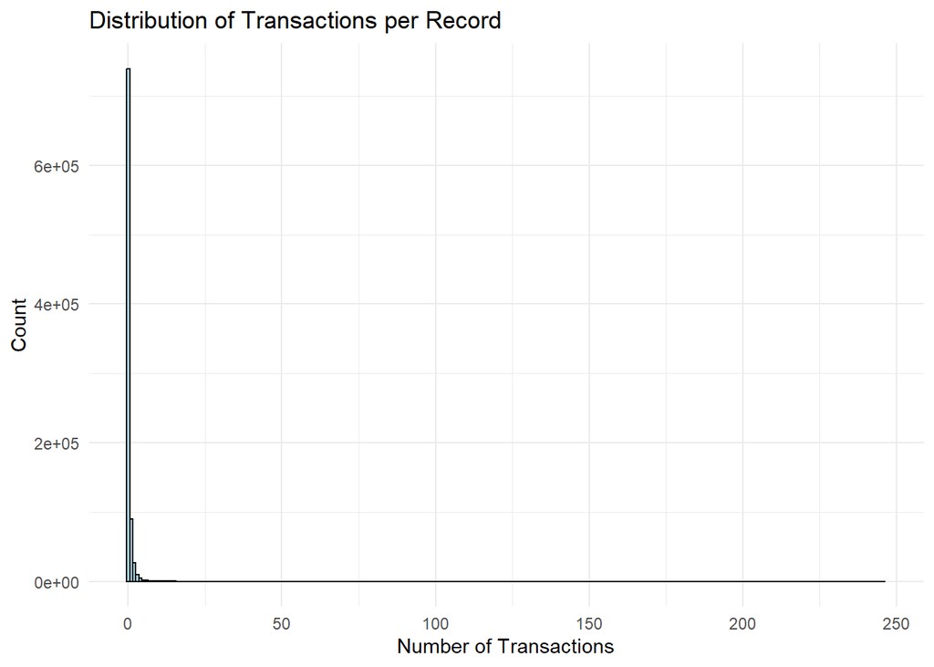

```r
final_database_filtered |>
    st_drop_geometry() |>
    ggplot(aes(x = transactions)) +
    geom_histogram(binwidth = 1, fill = "lightblue", color = "black") +
    labs(title = "Distribution of Transactions per Record", x = "Number of Transactions", y = "Count") +
    theme_minimal()
```

Several census tracts have no transactions at all. This is not a problem with the model to evaluate the effect of flood events on the number of transactions, but it prevent the model to evaluate the effect of flood events on the price of the transactions, as there are no transactions to evaluate the price. For now, we will keep the census tracts with no transactions, but we will need to filter them out when we run the model to evaluate the effect of flood events on the price of the transactions.

# Checking treatment support through all periods

```r
final_database_filtered |>
    st_drop_geometry() |>
    group_by(year, month) |>
    summarise(has_treatment = n_distinct(has_flood_event)>1) |>
    arrange(year, month) |>
    DT::datatable()
```

```
`summarise()` has regrouped the output.
ℹ Summaries were computed grouped by year and month.
ℹ Output is grouped by year.
ℹ Use `summarise(.groups = "drop_last")` to silence this message.
ℹ Use `summarise(.by = c(year, month))` for per-operation grouping
  (`?dplyr::dplyr_by`) instead.
```

|  | year | month | has_treatment |
| --- | --- | --- | --- |
| 1 | 2023 | 1 | True |
| 2 | 2023 | 2 | True |
| 3 | 2023 | 3 | True |
| 4 | 2023 | 4 | True |
| 5 | 2023 | 5 | True |
| 6 | 2023 | 6 | True |
| 7 | 2023 | 7 | False |
| 8 | 2023 | 8 | True |
| 9 | 2023 | 9 | True |
| 10 | 2023 | 10 | True |

[output cut: 26 more lines]

# Checking the balance between treated and control groups

```r
final_database_filtered |>
    st_drop_geometry() |>
    group_by(has_flood_event) |>
    # count distinct census tracts
    summarise(count = n_distinct(census_tract)) |>
    mutate(percentage = count / sum(count) * 100, percentage = round(percentage, 2)) |>
    arrange(desc(count)) |>
    DT::datatable()
```

|  | has_flood_event | count | percentage |
| --- | --- | --- | --- |
| 1 | 0 | 24319 | 95.54 |
| 2 | 1 | 1136 | 4.46 |